# Compound_Activity_Mixed_Effects_Model

SL Mondragón-González

Summer 2024

## Introduction

This R Notebook is dedicated to the analysis of experimental data obtained from a series of experiments designed to evaluate the effects of various DREADD compounds administered at different doses over time on the activity levels of test subjects. The subjects’ activity metrics were derived from video recordings by processing the body center’s instantaneous speed. These metrics are analyzed to assess the potential impacts of the compounds, focusing on key measurements such as:

- **Activity classifications:**
  - **High activity (%)**: The percentage of time the subject’s activity was classified as high, indicating periods of significant movement. It helps to evaluate the extent to which the compound increases or maintains high levels of activity.
  - **Low activity (%)**: The percentage of time the subject’s activity was classified as low, reflecting periods of minimal movement. It is useful for understanding whether the compound induces lethargy or reduces overall activity.
  - **Occlusion (%)**: The percentage of time during which the subject could not be tracked due to occlusion, meaning the subject’s body center was not visible or measurable. This metric is essential for assessing the quality and reliability of the tracking data.
- **Mean (px/s)**: The mean speed of the subject’s body center over the entire recording period. This provides a general sense of the subject’s overall activity level and is a direct indicator of how the compound might influence average movement speed.
- **Standard deviation (px/s)**: This measures the variability in the subject’s speed, reflecting how consistent or varied their activity was during the recording period. High variability might indicate erratic behavior, while low variability could suggest consistent activity levels.
- **Activity Distribution Ratios (ADR):**
  - **ADR Low/High+Occ**: The Activity Distribution Ratio (ADR) between low activity and the combined time of high activity and occlusion periods. This ratio helps to understand the relative dominance of low activity compared to periods of high activity or times when the subject was not trackable.
  - **ADR Low/High**: The Activity Distribution Ratio (ADR) between low and high activity periods. This metric is crucial for comparing the balance between periods of low and high activity, indicating how a compound may shift the subject’s behavior towards more or less activity.
- **Skewness:**
  - **Skewness low**: The skewness of the low activity distribution over time, indicating whether low activity periods are more concentrated at certain times during the experiment. A positive skew suggests that low activity occurs more frequently towards the end, while a negative skew indicates it is more common at the beginning.
  - **Skewness high**: The skewness of the high activity distribution over time, similar to the low activity skewness but focusing on periods of high activity. This metric helps to determine whether high activity is more likely at specific times during the experiment.
- **Normalized entropy**: This metric represents the entropy of the activity distribution across the entire recording, normalized to a maximum entropy value. Entropy measures the randomness or unpredictability of the activity states (high, low, occlusion). A higher normalized entropy suggests a more even distribution of these states, while lower entropy indicates that one state is dominant.”

### Additional Factors and Controls:

To ensure reliable analysis, two control conditions are incorporated:

Baseline activity: Measurements of activity metrics before the injection of any compound, used to account for the subject’s normal activity levels. Saline injections: A control condition where saline was injected instead of a compound, to determine whether observed effects are due to the compounds or just the injection process.

## Objectives

The primary objectives of this analysis are:

1. **Quantify the Effects of Compounds:** Determine whether the different compounds have a significant impact on various activity metrics, including high activity percentage, low activity percentage, and mean speed.
2. **Assess Dose-Response Relationships:** Explore how different doses influence the observed effects, and whether there is an interaction between compound type and dose.
3. **Time-Dependent Changes:** Analyze how activity metrics evolve over time post-injection, to identify any time-dependent effects of the compounds.
4. **Multivariate Analysis:** Perform Principal Component Analysis (PCA) to reduce dimensionality and identify the main drivers of variability in the activity metrics.
5. **Statistical Significance:** Apply appropriate statistical tests, such as ANOVA and mixed-effects models, to determine the significance of observed differences and relationships.

## 1. **Load and Inspect the Data**

```r
# Load the data
data <- read.csv("D:/OneDrive - ICM/Liz_NeuroMatlab/DLC_PoseAnalysis/Results/results.csv", sep = ",")

# View the first few rows to ensure the data has been loaded correctly
# head(data)

# Separate the relevant metadata (experiment descriptors) and the actual results
metadata <- data[, 1:4]   # Columns 1 to 4: ID, Compound, Dose, Post-injection time
results <- data[, 11:20]  # Columns 11 to 20: High activity percentage to entropy

# Convert the Compound column to a factor and Dose to numeric
metadata$Compound <- as.factor(metadata$Compound)
metadata$Dose..mg.kg. <- as.numeric(metadata$Dose..mg.kg.)
# Create a new column combining Compound and Dose
metadata <- metadata %>%
  mutate(Compound_Dose = paste(Compound, Dose..mg.kg., sep = "_"))

# Check the structure of the metadata and results to confirm they are as expected
# str(metadata)
# str(results)

# View summary statistics of the results to identify any potential issues or patterns
summary_results <- describe(results)
summary_results
```

|  | vars | n | mean | sd | median | trimmed | mad | min | max | range | skew | kurtosis | se |
| --- | --- | --- | --- | --- | --- | --- | --- | --- | --- | --- | --- | --- | --- |
| High.activity.percentage | 1 | 327 | 25.55 | 5.32 | 24.51 | 25.29 | 5.41 | 10.83 | 42.23 | 31.40 | 0.43 | -0.15 | 0.29 |
| Low.activity.percentage | 2 | 327 | 73.60 | 5.45 | 74.45 | 73.87 | 5.34 | 56.85 | 89.17 | 32.32 | -0.42 | -0.08 | 0.30 |
| Occlusion.percentage | 3 | 327 | 0.85 | 1.54 | 0.00 | 0.54 | 0.00 | 0.00 | 14.75 | 14.75 | 3.74 | 24.20 | 0.08 |
| Mean | 4 | 327 | 18.99 | 9.46 | 17.79 | 18.23 | 9.49 | 2.51 | 51.49 | 48.98 | 0.79 | 0.64 | 0.52 |
| Std.deviation | 5 | 327 | 22.60 | 11.61 | 20.97 | 21.75 | 12.50 | 1.33 | 71.47 | 70.14 | 0.69 | 0.31 | 0.64 |
| ADR.Low.High.Occ | 6 | 327 | 2.96 | 0.86 | 2.91 | 2.90 | 0.80 | 1.32 | 8.23 | 6.91 | 1.11 | 3.87 | 0.05 |
| ADR.Low.High | 7 | 327 | 3.05 | 0.87 | 3.03 | 3.00 | 0.85 | 1.37 | 8.23 | 6.86 | 1.01 | 3.28 | 0.05 |
| skewness_low | 8 | 327 | 0.00 | 0.19 | 0.00 | -0.01 | 0.16 | -0.56 | 0.65 | 1.21 | 0.17 | 0.81 | 0.01 |
| skewness_high | 9 | 327 | -0.02 | 0.53 | 0.04 | 0.00 | 0.44 | -1.78 | 1.84 | 3.62 | -0.40 | 1.03 | 0.03 |
| normalized.entropy | 10 | 327 | 0.38 | 0.05 | 0.37 | 0.37 | 0.04 | 0.21 | 0.55 | 0.34 | 0.39 | 0.56 | 0.00 |

```r
# Integrate metadata with results for further analysis
data_combined <- cbind(metadata, results)

# Custom order for Compound_Dose
custom_order <- c("21_1", "21_3", "21_5", "21_10",
                  "j52nws_0.5", "j52nws_1", "j52ws_0.5", "j52ws_1",
                  "j60nws_0.5", "j60nws_1", "j60ws_0.5", "j60ws_1",
                  "cno_3", "Saline_0")

# Set the levels of the Compound_Dose factor
data_combined$Compound_Dose <- factor(data_combined$Compound_Dose, levels = custom_order)
```

## 2. **Exploratory Data Analysis (EDA)**

Question 1: What is the distribution of activity metrics across different compounds, doses, and time point

```r
# Summary statistics for key metrics grouped by Compound_Dose and Post.injection..h.
summary_stats <- data_combined %>%
  group_by(Compound_Dose, Post.injection..h.) %>%
  summarise(
    mean_high_activity = round(mean(High.activity.percentage, na.rm = TRUE), 2),
    mean_low_activity = round(mean(Low.activity.percentage, na.rm = TRUE), 2),
    mean_occlusion = round(mean(Occlusion.percentage, na.rm = TRUE), 2),
    mean_speed = round(mean(Mean, na.rm = TRUE), 2),
    sd_speed = round(mean(Std.deviation, na.rm = TRUE), 2),
    mean_adr_low_high_occ = round(mean(ADR.Low.High.Occ, na.rm = TRUE), 2),
    mean_adr_low_high = round(mean(ADR.Low.High, na.rm = TRUE), 2),
    mean_skewness_low = round(mean(skewness_low, na.rm = TRUE), 2),
    mean_skewness_high = round(mean(skewness_high, na.rm = TRUE), 2),
    mean_entropy = round(mean(normalized.entropy, na.rm = TRUE), 2)
  )
# Print the summary statistics
print(summary_stats)
```

| Compound_Dose | Post.injection..h. | mean_high_activity | mean_low_activity | mean_occlusion | mean_speed | sd_speed | mean_adr_low_high_occ | mean_adr_low_high | mean_skewness_low | mean_skewness_high | mean_entropy |
| --- | --- | --- | --- | --- | --- | --- | --- | --- | --- | --- | --- |
| 21_1 | 0 | 29.37 | 69.82 | 0.81 | 20.84 | 26.87 | 2.44 | 2.47 | -0.06 | -0.02 | 0.40 |
| 21_1 | 1 | 26.36 | 71.73 | 1.90 | 15.11 | 15.29 | 2.76 | 2.92 | 0.01 | 0.07 | 0.41 |
| 21_1 | 2 | 24.36 | 74.87 | 0.77 | 22.19 | 23.17 | 3.07 | 3.18 | -0.04 | 0.23 | 0.37 |
| 21_1 | 4 | 28.96 | 70.11 | 0.92 | 18.83 | 23.59 | 2.59 | 2.64 | -0.12 | 0.12 | 0.40 |
| 21_1 | 6 | 22.41 | 77.59 | 0.00 | 24.97 | 28.54 | 3.52 | 3.52 | -0.15 | 0.42 | 0.33 |
| 21_1 | 8 | 23.33 | 75.98 | 0.69 | 26.23 | 31.30 | 3.38 | 3.61 | 0.04 | -0.02 | 0.36 |
| 21_1 | 10 | 23.49 | 75.31 | 1.20 | 29.70 | 34.61 | 3.08 | 3.22 | 0.03 | -0.23 | 0.38 |
| 21_3 | 0 | 25.31 | 74.07 | 0.62 | 25.47 | 27.58 | 3.03 | 3.14 | 0.02 | -0.16 | 0.36 |
| 21_3 | 1 | 24.07 | 75.36 | 0.57 | 21.19 | 22.72 | 3.19 | 3.30 | 0.01 | 0.20 | 0.36 |
| 21_3 | 2 | 25.37 | 72.90 | 1.73 | 22.40 | 27.92 | 2.74 | 3.00 | 0.04 | 0.00 | 0.40 |

[output cut: 67 more lines]

```r
NA
```

## 2.1 **Plotting**

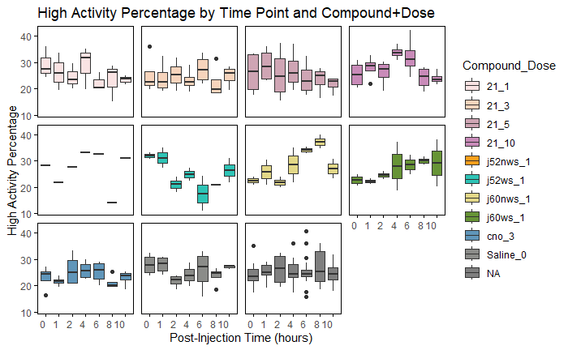

```r
# Define custom color palette
color_palette <- c(
  "21_1" = "#fae3e3",   # Misty rose
  "21_3" = "#f7d4bc",   # Desert sand
  "21_5" = "#cfa5b4",   # Pink lavander
  "21_10" = "#c98bb9",  # African violet
  "j52nws_0.5" = "#ffbf69",  # Hunyadi yellow
  "j52nws_1" = "#ff9f1c",    # Orange peel
  "j52ws_0.5" = "#cbf3f0",   # Mint green
  "j52ws_1" = "#2ec4b6",     # Light sea green
  "j60nws_0.5" = "#e2f1af",  # Tea green
  "j60nws_1" = "#e3d888",    # Flax
  "j60ws_0.5" = "#a5be00",   # Apple green
  "j60ws_1" = "#679436",     # Asparagus
  "cno_3" = "#6096ba",       # Air blue
  "Saline_0" = "#8b8c89"     # Battleship gray
)

# Function to generate the plot
# Function to generate the plot with consistent y-axis limits
plot_metric <- function(metric_name, y_label) {
  # Calculate the global min and max for the metric across all groups
  y_min <- min(data_combined[[metric_name]], na.rm = TRUE)
  y_max <- max(data_combined[[metric_name]], na.rm = TRUE)

  ggplot(data_combined, aes(x = as.factor(Post.injection..h.), y = .data[[metric_name]], fill = Compound_Dose)) +
    geom_boxplot() +
    facet_wrap(~ Compound_Dose, scales = "fixed", ncol = 4) +
    labs(title = paste(y_label, "by Time Point and Compound+Dose"),
         x = "Post-Injection Time (hours)", y = y_label) +
    scale_fill_manual(values = color_palette) +
    expand_limits(y = c(y_min, y_max)) +  # Apply the global min and max to all subplots
    theme_classic() +
    theme(
      axis.text.x = element_text(angle = 0, hjust = 1),
      strip.text = element_blank(),  # Remove facet labels
      panel.spacing = unit(0.5, "lines"),  # Control spacing between panels
      axis.line = element_line(color = "black"),  # Ensure axis lines are visible
      axis.ticks = element_line(color = "black"),  # Ensure ticks are visible
      panel.border = element_rect(fill = NA, color = "black")  # Add a border around each panel
    )
}


# Generate plots for all 10 metrics
p_high_activity <- plot_metric("High.activity.percentage", "High Activity Percentage")
p_low_activity <- plot_metric("Low.activity.percentage", "Low Activity Percentage")
p_mean_speed <- plot_metric("Mean", "Mean Speed (px/s)")
p_sd_speed <- plot_metric("Std.deviation", "Speed Standard Deviation (px/s)")
p_occlusion <- plot_metric("Occlusion.percentage", "Occlusion Percentage")
p_adr_low_high_occ <- plot_metric("ADR.Low.High.Occ", "ADR Low/High+Occ")
p_adr_low_high <- plot_metric("ADR.Low.High", "ADR Low/High")
p_skewness_low <- plot_metric("skewness_low", "Skewness Low")
p_skewness_high <- plot_metric("skewness_high", "Skewness High")
p_entropy <- plot_metric("normalized.entropy", "Normalized Entropy")

# Display the plots
p_high_activity
```

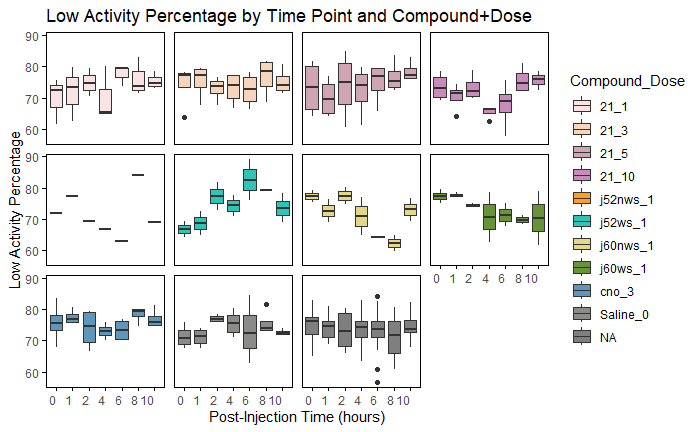

```r
p_low_activity
```

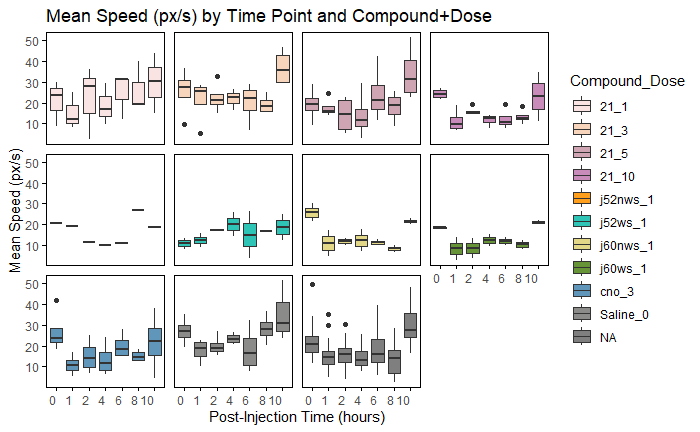

```r
p_mean_speed
```

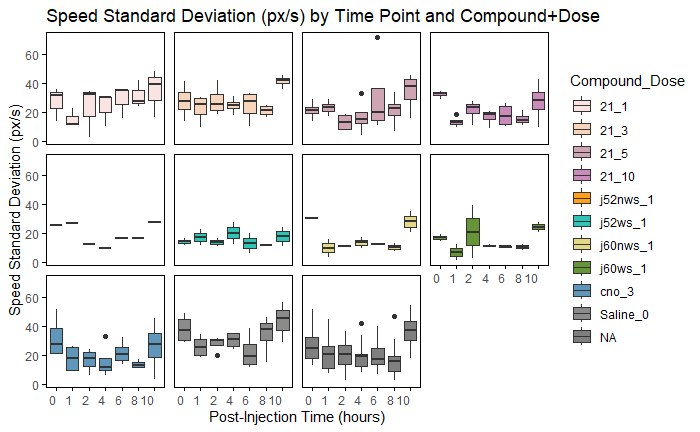

```r
p_sd_speed
```

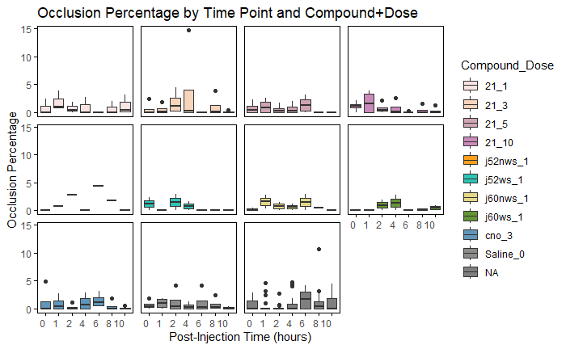

```r
p_occlusion
```

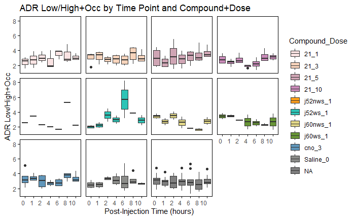

```r
p_adr_low_high_occ
```

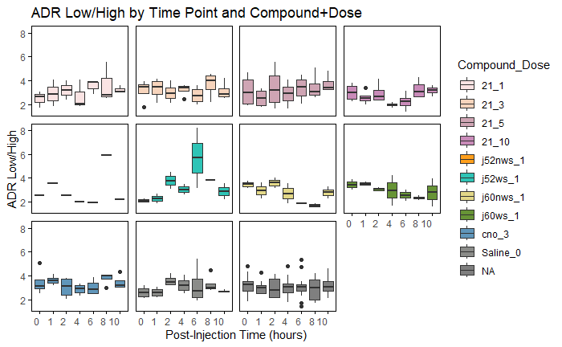

```r
p_adr_low_high
```

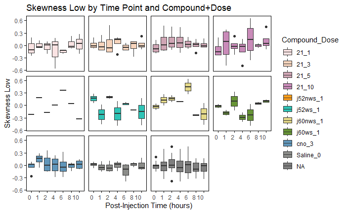

```r
p_skewness_low
```

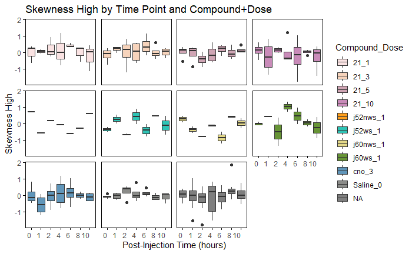

```r
p_skewness_high
```

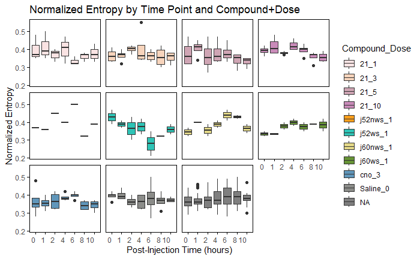

```r
p_entropy
```

## 3. Visualize correlation matrix

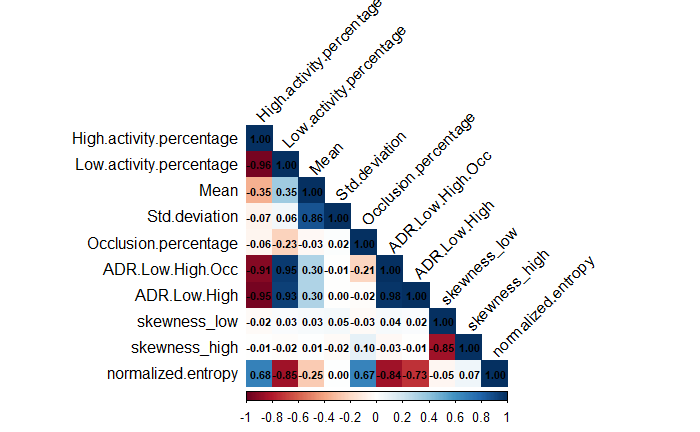

```r
# Calculate the correlation matrix for the metrics
metrics <- c("High.activity.percentage", "Low.activity.percentage", "Mean", "Std.deviation","Occlusion.percentage",
             "ADR.Low.High.Occ", "ADR.Low.High", "skewness_low", "skewness_high", "normalized.entropy")

correlation_matrix <- cor(data_combined[, metrics], use = "complete.obs")

# Plot the correlation matrix as a heatmap
library(corrplot)
corrplot(correlation_matrix, method = "color", type = "lower",
         tl.col = "black", tl.srt = 45,
         addCoef.col = "black", number.cex = 0.7)
```

**Reminder:** Correlation close to +1 means there is a strong positive correlation between the two variables, this suggests that the two variables move in the same direction.

**Main results and their interpretation:**

- **Std.deviation and Mean**: the average speed of the subject increases, the variability in their speed also increases suggesting that subjects that are moving faster on average tend to have more variability in their speed, indicating that higher speed is associated with more erratic or varied movement patterns.
- **ADR Low/High+Occlusion and Low activity percentage**: the percentage of time spent in low activity increases, the ratio of low activity to other states also increases. *What This Means:* When subjects spend more time in low activity, it significantly dominates their behavior relative to periods of high activity and times when they are not trackable. –> Not a surprise, maybe use one metrics only for the anova.
- **ADR Low/High and Low activity percentage:** the percentage of time spent in low activity increases, the ratio of low to high activity also increases. *What This Means*: Subjects that spend more time in low activity have a much greater proportion of low activity compared to high activity, reinforcing the idea that certain compounds might be reducing overall activity levels.–> Not a surprise, maybe use one metrics only for the anova.
- **ADR Low/High and Low and ADR Low/High+Occlusion:** as the ratio of low to high activity increases, so does the ratio of low activity to the combination of high activity and occlusion. *What this means:* This correlation indicates that the dominance of low activity is consistent whether considering just high activity or including periods of occlusion. It reinforces that subjects with higher low activity tend to have lower periods of high activity, regardless of occlusion.–> Not a surprise, maybe use one metrics only for the anova.
- **Normalized entropy and Occlusion percentage**: Higher occlusion rates, where the subject’s movement cannot be tracked, lead to a more unpredictable and evenly distributed activity state. This could indicate that occlusion introduces uncertainty in tracking, leading to higher entropy values. –> Not a surprise, focus on the outliers and verify the problem in the video, maybe identify a slightly different time window?

**General conclusion:**

The analysis reveals that subjects with higher average speeds exhibit more variable movement patterns, suggesting that increased activity often leads to more erratic behavior. Additionally, higher low activity percentages correlate strongly with higher ratios of low activity to other states. To avoid multicollinearity and focus on the most informative metrics, I would suggest to concentrate on the **`ADR Low/High + Occlusion`** metric in further analyses, and exclude redundant metrics like `ADR Low/High`, and `Low activity percentage` from the ANOVA.

Moreover, the observation that higher occlusion rates lead to increased randomness in activity distribution indicates potential challenges in predicting subject behavior when tracking is incomplete. Recordings with high occlusion should be reviewed to identify and address any underlying issues. Depending on the findings, it may be necessary to consider removing these recordings from the analysis or selecting alternative time windows, even if they differ from those used in other experiments, to ensure the reliability of the data.

## 4. PCA Biplot

**Reminder:** This is a useful analysis to:

1. Identify which metrics are most influential in explaining the variance in my data.
2. Reduce dimensionality: How many metrics I need to consider (the first principal components). These are the ones I should focus, and ignore the others, to simplify my analysis.
3. Are there distinct groups of observations? The positions of the points (scores) can reveal if there are natural groupings of your subjects or experiments. This might suggest that certain compounds or doses lead to similar activity patterns.

```r
# Load necessary libraries
library(ggbiplot)
library(ggplot2)

# List of metrics to include in PCA
metrics <- c("High.activity.percentage", "Mean",
              "Occlusion.percentage", "ADR.Low.High.Occ",
              "skewness_low", "skewness_high", "normalized.entropy")

# Perform PCA on the standardized metrics
pca_result <- prcomp(data_combined[, metrics], scale. = TRUE)

# Summary of PCA to see the proportion of variance explained by each component
summary(pca_result)
```

```
Importance of components:
                          PC1    PC2    PC3    PC4     PC5     PC6     PC7
Standard deviation     1.7041 1.3596 1.1045 0.9011 0.38584 0.21729 0.14034
Proportion of Variance 0.4148 0.2641 0.1743 0.1160 0.02127 0.00674 0.00281
Cumulative Proportion  0.4148 0.6789 0.8532 0.9692 0.99044 0.99719 1.00000
```

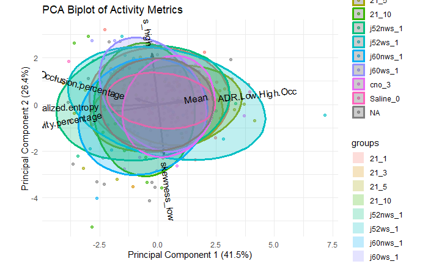

```r
# Plot the PCA biplot
pca_biplot <- ggbiplot(pca_result, ellipse = TRUE, obs.scale = 1, var.scale = 1,
                       groups = data_combined$Compound_Dose,
                       varname.size = 4, alpha = 0.6) +
  scale_color_discrete(name = '') +
  theme_minimal() +
  labs(title = "PCA Biplot of Activity Metrics",
       x = paste("Principal Component 1 (", round(summary(pca_result)$importance[2,1] * 100, 1), "%)", sep = ""),
       y = paste("Principal Component 2 (", round(summary(pca_result)$importance[2,2] * 100, 1), "%)", sep = ""))

# Print the biplot
print(pca_biplot)
```

```r
# Extract the loadings (eigenvectors) for each principal component
loadings <- pca_result$rotation

# View the loadings for PC1 and PC2
loadings_pc1_pc2 <- loadings[, 1:2]
print(loadings_pc1_pc2)
```

```
                                 PC1         PC2
High.activity.percentage -0.50183954 -0.10840010
Mean                      0.25916377  0.05333202
Occlusion.percentage     -0.24866364  0.08212264
ADR.Low.High.Occ          0.55526088  0.07233917
skewness_low              0.06875959 -0.69421303
skewness_high            -0.06932024  0.70090279
normalized.entropy       -0.54891692 -0.01521755
```

```r
# Identify the metrics with the highest absolute loadings on PC1 and PC2
high_loadings_pc1 <- sort(abs(loadings_pc1_pc2[, 1]), decreasing = TRUE)
high_loadings_pc2 <- sort(abs(loadings_pc1_pc2[, 2]), decreasing = TRUE)

cat("Metrics contributing most to PC1:\n")
```

```
Metrics contributing most to PC1:
```

```r
print(names(high_loadings_pc1[1:3])) # Top 3 metrics for PC1
```

```
[1] "ADR.Low.High.Occ"         "normalized.entropy"       "High.activity.percentage"
```

```r
cat("\nMetrics contributing most to PC2:\n")
```

```
Metrics contributing most to PC2:
```

```r
print(names(high_loadings_pc2[1:3])) # Top 3 metrics for PC2
```

```
[1] "skewness_high"            "skewness_low"             "High.activity.percentage"
```

## 5. Two-way ANOVA

In this analysis, we use a two-way ANOVA to understand how different compounds and their doses, and the time after injection affect various activity metrics of the subjects. Specifically, the two-way ANOVA helps us answer two key questions:

**Main Effects:**

- Does the type of compound and dose affect the subjects’ activity?
- Does the time after injection (e.g., 1 hour, 2 hours) affect the subjects’ activity?

**Interaction Effect:**

- Does the effect of the compound and its dose change over time? For example, does a particular compound increase activity more at 2 hours post-injection than at 1 hour?

```
Analyzing Metric: Occlusion.percentage
```

```
Levene's Test for Homogeneity of Variance:
Levene's Test for Homogeneity of Variance (center = median)
       Df F value Pr(>F)
group  69  0.6418 0.9793
      138

Variance Inflation Factor (VIF):
```

```
there are higher-order terms (interactions) in this model
consider setting type = 'predictor'; see ?vif
```

```
                                         GVIF Df GVIF^(1/(2*Df))
Compound_Dose                    3.648038e+07  9        2.630961
Post.injection..h.               9.434295e+05  6        3.146969
Compound_Dose:Post.injection..h. 7.842135e+12 54        1.316415
Warning: Issue with sum of squares or degrees of freedom in metric: Occlusion.percentage


Analyzing Metric: ADR.Low.High.Occ
```

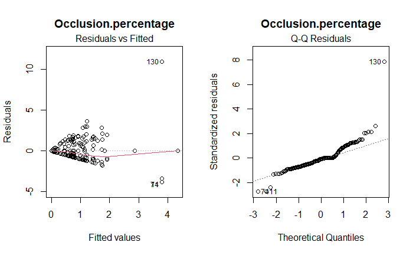

```
Levene's Test for Homogeneity of Variance:
Levene's Test for Homogeneity of Variance (center = median)
       Df F value   Pr(>F)
group  69  1.6049 0.009724 **
      138
---
Signif. codes:  0 ‘***’ 0.001 ‘**’ 0.01 ‘*’ 0.05 ‘.’ 0.1 ‘ ’ 1

Variance Inflation Factor (VIF):
```

```
there are higher-order terms (interactions) in this model
consider setting type = 'predictor'; see ?vif
```

```
                                         GVIF Df GVIF^(1/(2*Df))
Compound_Dose                    3.648038e+07  9        2.630961
Post.injection..h.               9.434295e+05  6        3.146969
Compound_Dose:Post.injection..h. 7.842135e+12 54        1.316415
Warning: Issue with sum of squares or degrees of freedom in metric: ADR.Low.High.Occ


Analyzing Metric: skewness_low
```

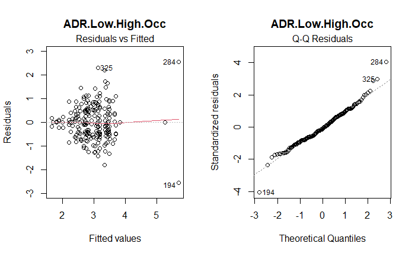

```
Levene's Test for Homogeneity of Variance:
Levene's Test for Homogeneity of Variance (center = median)
       Df F value  Pr(>F)
group  69  1.3698 0.06031 .
      138
---
Signif. codes:  0 ‘***’ 0.001 ‘**’ 0.01 ‘*’ 0.05 ‘.’ 0.1 ‘ ’ 1

Variance Inflation Factor (VIF):
```

```
there are higher-order terms (interactions) in this model
consider setting type = 'predictor'; see ?vif
```

```
                                         GVIF Df GVIF^(1/(2*Df))
Compound_Dose                    3.648038e+07  9        2.630961
Post.injection..h.               9.434295e+05  6        3.146969
Compound_Dose:Post.injection..h. 7.842135e+12 54        1.316415
Warning: Issue with sum of squares or degrees of freedom in metric: skewness_low


Analyzing Metric: skewness_high
```

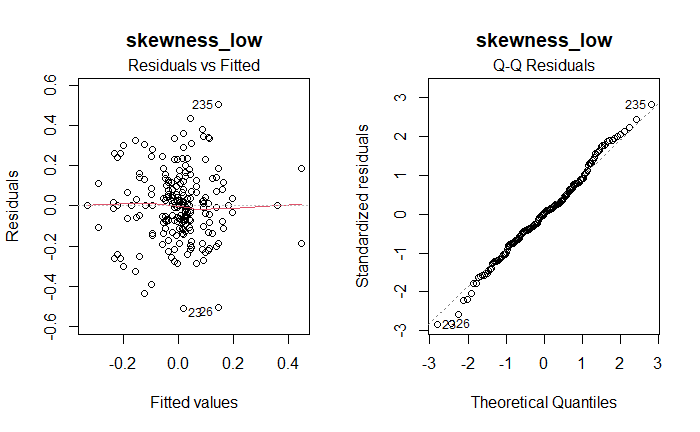

```
Levene's Test for Homogeneity of Variance:
Levene's Test for Homogeneity of Variance (center = median)
       Df F value Pr(>F)
group  69  1.2199 0.1625
      138

Variance Inflation Factor (VIF):
```

```
there are higher-order terms (interactions) in this model
consider setting type = 'predictor'; see ?vif
```

```
                                         GVIF Df GVIF^(1/(2*Df))
Compound_Dose                    3.648038e+07  9        2.630961
Post.injection..h.               9.434295e+05  6        3.146969
Compound_Dose:Post.injection..h. 7.842135e+12 54        1.316415
Warning: Issue with sum of squares or degrees of freedom in metric: skewness_high


Analyzing Metric: normalized.entropy
```

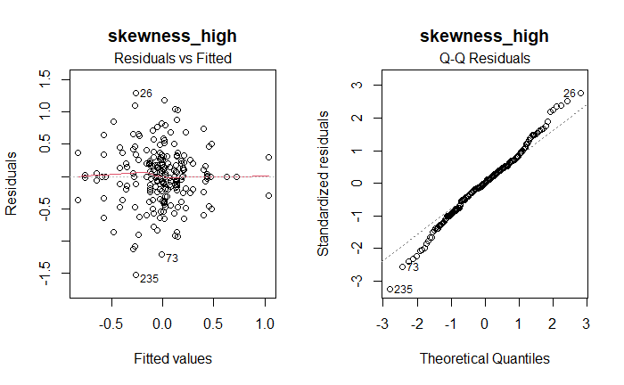

```
Levene's Test for Homogeneity of Variance:
Levene's Test for Homogeneity of Variance (center = median)
       Df F value Pr(>F)
group  69  0.9741 0.5407
      138

Variance Inflation Factor (VIF):
```

```
there are higher-order terms (interactions) in this model
consider setting type = 'predictor'; see ?vif
```

```
                                         GVIF Df GVIF^(1/(2*Df))
Compound_Dose                    3.648038e+07  9        2.630961
Post.injection..h.               9.434295e+05  6        3.146969
Compound_Dose:Post.injection..h. 7.842135e+12 54        1.316415
Warning: Issue with sum of squares or degrees of freedom in metric: normalized.entropy
```

```r
# Ensure that Compound_Dose and Post.injection..h. are factors
data_combined$Compound_Dose <- as.factor(data_combined$Compound_Dose)
data_combined$Post.injection..h. <- as.factor(data_combined$Post.injection..h.)

# Perform Two-Way ANOVA, Tukey's HSD, and Power Analysis for each metric
two_way_anova_results <- list()
tukey_hsd_results <- list()
diagnostic_plots <- list()  # To store diagnostic plots
power_analysis_results <- list()  # To store power analysis results

metrics <- c("Occlusion.percentage", "ADR.Low.High.Occ",
             "skewness_low", "skewness_high", "normalized.entropy")

for (metric in metrics) {
  cat("\n\nAnalyzing Metric:", metric, "\n")

  # Build the ANOVA model with both factors
  anova_result <- aov(data_combined[[metric]] ~ Compound_Dose * Post.injection..h., data = data_combined)

  # Store the summary of the ANOVA results
  two_way_anova_results[[metric]] <- summary(anova_result)

  # Perform Tukey's HSD post-hoc test
  tukey_result <- tryCatch({
    TukeyHSD(anova_result)
  }, error = function(e) {
    message("Error in TukeyHSD for metric: ", metric, "\n", e)
    return(NULL)
  })

  # Store the TukeyHSD results
  tukey_hsd_results[[metric]] <- tukey_result

  # Diagnostic plots: Residuals vs Fitted and Q-Q plot
  par(mfrow = c(1, 2))
  plot(anova_result, which = 1:2, main = metric)

  # Store diagnostic plots
  diagnostic_plots[[metric]] <- recordPlot()

  # Test for homogeneity of variance (Levene's Test)
  levene_test <- leveneTest(data_combined[[metric]] ~ Compound_Dose * Post.injection..h., data = data_combined)
  cat("\nLevene's Test for Homogeneity of Variance:\n")
  print(levene_test)

  # Check for multicollinearity using VIF
  cat("\nVariance Inflation Factor (VIF):\n")
  print(vif(anova_result))

  # Power Analysis
  # Calculate the effect size based on the sum of squares between and within
  ss_between <- sum(anova_result$`Sum Sq`[c(1, 2)])  # Sum of squares for Compound_Dose and interaction
  ss_within <- sum(anova_result$`Sum Sq`[-c(1, 2)])  # Sum of squares for Residuals
  df_between <- sum(anova_result$Df[c(1, 2)])  # Degrees of freedom for Compound_Dose and interaction
  df_within <- sum(anova_result$Df[-c(1, 2)])  # Degrees of freedom for Residuals

  # Check if any of these values are NA or problematic
  if (is.na(ss_between) || is.na(ss_within) || ss_within == 0 || df_within == 0) {
    cat("Warning: Issue with sum of squares or degrees of freedom in metric:", metric, "\n")
    next  # Skip to the next metric
  }

  effect_size <- sqrt((ss_between / df_between) / (ss_within / df_within))  # Correct calculation of Cohen's f

  if (is.na(effect_size) || effect_size <= 0) {
    cat("Warning: Invalid effect size calculated for metric:", metric, "\n")
    next  # Skip to the next metric
  }

  # Calculate power using pwr.anova.test
  n_groups <- length(unique(data_combined$Compound_Dose)) * length(unique(data_combined$Post.injection..h.))
  n_per_group <- nrow(data_combined) / n_groups  # Calculate the number of observations per group
  power_analysis <- pwr.anova.test(k = n_groups, n = n_per_group, f = effect_size, sig.level = 0.05)

  # Store power analysis results
  power_analysis_results[[metric]] <- power_analysis
  cat("\nPower Analysis for Metric:", metric, "\n")
  print(power_analysis)
}
```

```r
# Print ANOVA results for all metrics
for (metric in metrics) {
  cat("\n\nTwo-Way ANOVA Results for Metric:", metric, "\n")
  print(two_way_anova_results[[metric]])
  cat("\n------------------------------------------------------------\n")

  # Print only significant Tukey HSD results
  if (!is.null(tukey_hsd_results[[metric]])) {
    cat("\nSignificant Tukey HSD Post-Hoc Results for Metric:", metric, "\n")

    # Extract the significant comparisons
    tukey_result <- tukey_hsd_results[[metric]]
    significant_comparisons <- list()

    for (comparison in names(tukey_result)) {
      significant <- tukey_result[[comparison]][, "p adj"] < 0.05
      if (any(significant)) {
        significant_comparisons[[comparison]] <- tukey_result[[comparison]][significant, ]
      }
    }

    # Print only the significant comparisons
    if (length(significant_comparisons) > 0) {
      print(significant_comparisons)
    } else {
      cat("No significant post-hoc comparisons.\n")
    }

    cat("\n------------------------------------------------------------\n")
  }
}
```

```
Two-Way ANOVA Results for Metric: Occlusion.percentage
                                  Df Sum Sq Mean Sq F value Pr(>F)
Compound_Dose                      9    9.3   1.038   0.402  0.932
Post.injection..h.                 6   17.8   2.968   1.150  0.337
Compound_Dose:Post.injection..h.  54   83.3   1.542   0.597  0.984
Residuals                        138  356.3   2.582
119 observations effacées parce que manquantes

------------------------------------------------------------

Significant Tukey HSD Post-Hoc Results for Metric: Occlusion.percentage
No significant post-hoc comparisons.

------------------------------------------------------------


Two-Way ANOVA Results for Metric: ADR.Low.High.Occ
                                  Df Sum Sq Mean Sq F value Pr(>F)
Compound_Dose                      9   8.51  0.9459   1.201  0.299
Post.injection..h.                 6   7.39  1.2316   1.563  0.162
Compound_Dose:Post.injection..h.  54  48.52  0.8984   1.140  0.269
Residuals                        138 108.71  0.7878
119 observations effacées parce que manquantes

------------------------------------------------------------

Significant Tukey HSD Post-Hoc Results for Metric: ADR.Low.High.Occ
$`Compound_Dose:Post.injection..h.`
                        diff         lwr        upr       p adj
j52ws_1:6-21_10:1     3.2825  0.01435401  6.5506460 0.047028725
j52ws_1:6-21_10:4     3.7925  0.52435401  7.0606460 0.004088879
j52ws_1:6-21_10:6     3.4700  0.20185401  6.7381460 0.020283440
j60nws_1:6-j52ws_1:6 -3.8800 -7.65372994 -0.1062701 0.033492231
j60nws_1:8-j52ws_1:6 -4.0300 -7.80372994 -0.2562701 0.018458103


------------------------------------------------------------


Two-Way ANOVA Results for Metric: skewness_low
```

[output cut: 32 more lines]

```
                                  Df  Sum Sq  Mean Sq F value Pr(>F)
Compound_Dose                      9 0.01871 0.002078   0.907 0.5211
Post.injection..h.                 6 0.02933 0.004888   2.133 0.0533 .
Compound_Dose:Post.injection..h.  54 0.11520 0.002133   0.931 0.6098
Residuals                        138 0.31619 0.002291
---
Signif. codes:  0 ‘***’ 0.001 ‘**’ 0.01 ‘*’ 0.05 ‘.’ 0.1 ‘ ’ 1
119 observations effacées parce que manquantes

------------------------------------------------------------

Significant Tukey HSD Post-Hoc Results for Metric: normalized.entropy
No significant post-hoc comparisons.

------------------------------------------------------------
```

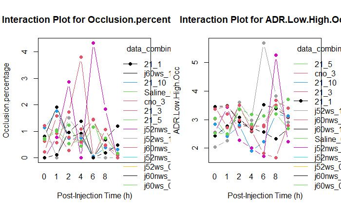

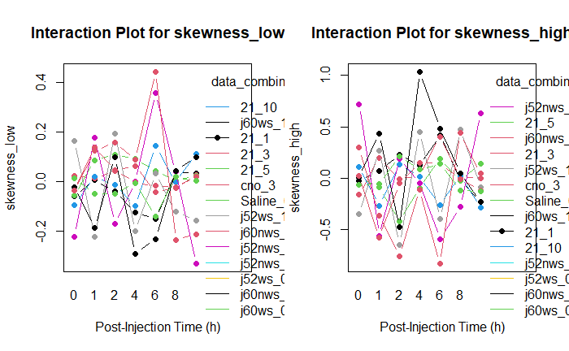

```r
# Interaction Plots
for (metric in metrics) {
  interaction.plot(data_combined$Post.injection..h.,
                   data_combined$Compound_Dose,
                   data_combined[[metric]],
                   col = 1:length(unique(data_combined$Compound_Dose)),
                   lty = 1, pch = 19, type = "b",
                   main = paste("Interaction Plot for", metric),
                   xlab = "Post-Injection Time (h)",
                   ylab = metric)
}
```

```r
# Display all diagnostic plots
for (metric in metrics) {
  cat("\nDiagnostic Plots for Metric:", metric, "\n")
  replayPlot(diagnostic_plots[[metric]])
}
```

```
Diagnostic Plots for Metric: Occlusion.percentage

Diagnostic Plots for Metric: ADR.Low.High.Occ

Diagnostic Plots for Metric: skewness_low

Diagnostic Plots for Metric: skewness_high

Diagnostic Plots for Metric: normalized.entropy
```

[output not shown]

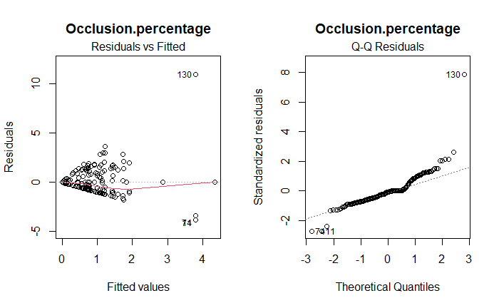

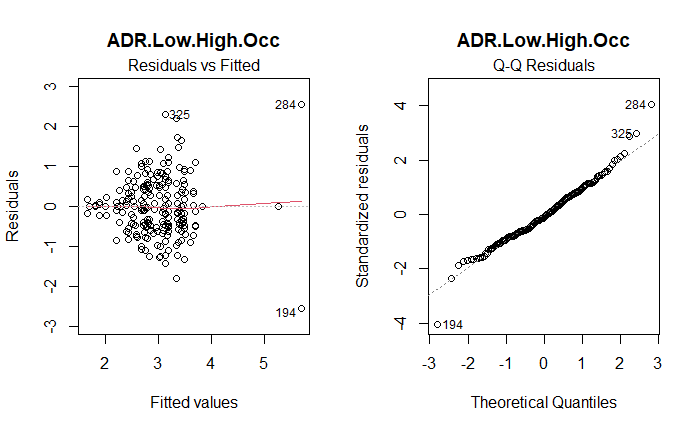

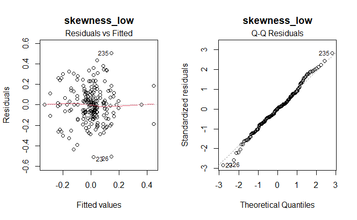

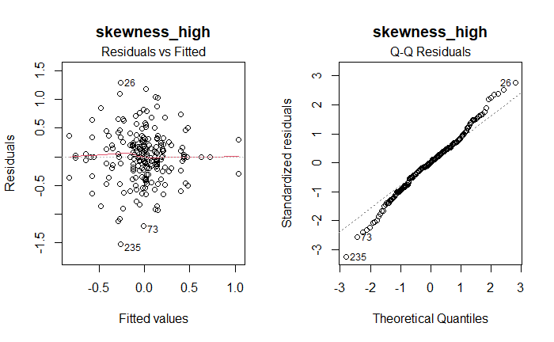

```r
# Display power analysis results
for (metric in metrics) {
  cat("\nPower Analysis Results for Metric:", metric, "\n")
  print(power_analysis_results[[metric]])
}
```

[output not shown]